# Choropleth Maps

## Base R Plotting

A choropleth map displays divided geographic regions that are colored in relation to some numerical value. The `maps` library provides some basic maps for you to do some quick visualization. Here is a map of the continental US.

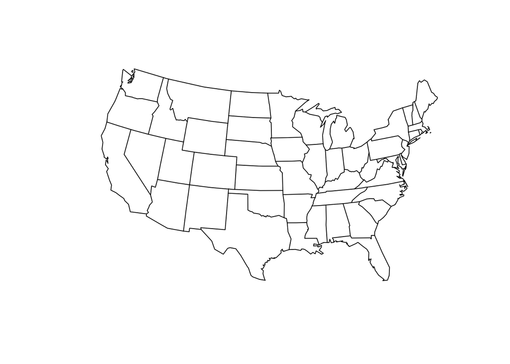

```r
library(maps)
map('state', projection = "polyconic" )
```

I grabbed some census data from the US Census site for each state and saved it as a CSV file. It is currently hosted on a Github site I use for all my ENVS teaching and we can read it directly from Github using the URL.

```r
library(readr)
url <- "https://raw.githubusercontent.com/dyerlab/ENVS-Lectures/master/lectures/spatial/chloropleth_maps/states.csv"
sz <- read_csv( url )
head(sz)
```

| name | population |
| --- | --- |
| alabama | 4.779736 |
| arizona | 6.392017 |
| arkansas | 2.915918 |
| california | 37.253956 |
| colorado | 5.029196 |
| connecticut | 3.574097 |

In this data set, there are 48 states (Hawaii & Alaska are not there) and the District of Columbia. To color these, I’m going to use a color palette defined in the `RColorBrewer` library that goes from yellow to orange to red. This is a sequential color ramp (see `brewer.pal.info` for other palettes).

```r
library(RColorBrewer)
colors <- brewer.pal(9,"YlOrRd")
colors
```

```
[1] "#FFFFCC" "#FFEDA0" "#FED976" "#FEB24C" "#FD8D3C" "#FC4E2A" "#E31A1C"
[8] "#BD0026" "#800026"
```

[output not shown]

Then I’m going stretch these colors out from 9 distinct colors to 49 colors, one for each State and D.C.

```r
colors <- colorRampPalette( colors )(49)
colors
```

```
 [1] "#FFFFCC" "#FFFCC4" "#FFF9BD" "#FFF6B6" "#FFF3AE" "#FFF0A7" "#FFEDA0"
 [8] "#FEE999" "#FEE692" "#FEE38B" "#FEDF84" "#FEDC7D" "#FED976" "#FED26F"
[15] "#FECC68" "#FEC561" "#FEBF5A" "#FEB853" "#FEB24C" "#FDAB49" "#FDA546"
[22] "#FD9F44" "#FD9941" "#FD933E" "#FD8D3C" "#FC8239" "#FC7836" "#FC6D33"
[29] "#FC6330" "#FC582D" "#FC4E2A" "#F74527" "#F33C25" "#EF3423" "#EB2B20"
[36] "#E7221E" "#E31A1C" "#DC151D" "#D6111F" "#D00D20" "#C90822" "#C30424"
[43] "#BD0026" "#B20026" "#A80026" "#9E0026" "#940026" "#8A0026" "#800026"
```

[output not shown]

[output cut: 42 more lines]

[output not shown]

```r
groups <- cut( sz$population, 49 )
sz$colors <- colors[ groups ]
head(sz)
```

| name | population | colors |
| --- | --- | --- |
| alabama | 4.779736 | #FFF0A7 |
| arizona | 6.392017 | #FEE999 |
| arkansas | 2.915918 | #FFF6B6 |
| california | 37.253956 | #800026 |
| colorado | 5.029196 | #FFF0A7 |
| connecticut | 3.574097 | #FFF3AE |

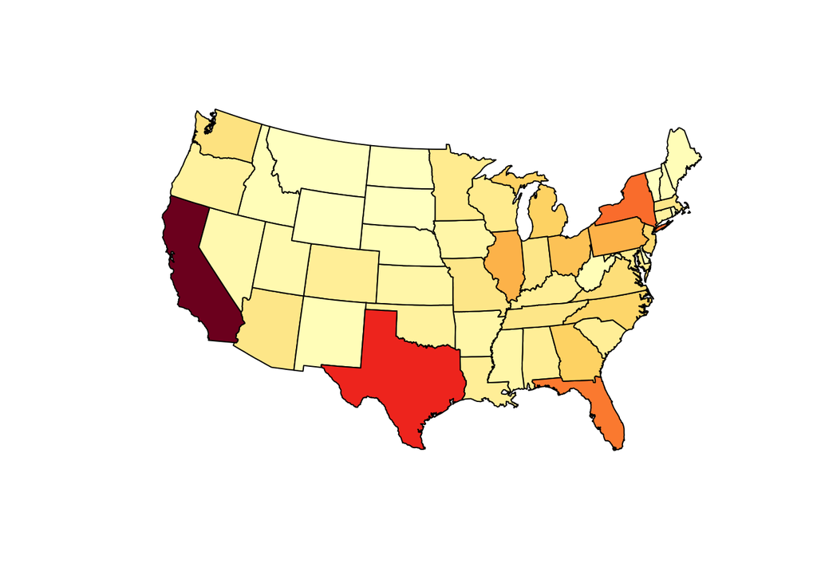

```r
map( 'state',
     col=sz$colors,
     fill=TRUE,
     projection="polyconic")
```